# P2_titanic

## P2 泰坦尼克号数据分析

- 数据来源：Kaggle
- 分析目的：有哪些因素会让船上的人生存率更高？
- 提出问题：

  > 影响生存率有很多种因素，本次分析主要针对乘客的性别、年龄、舱位这三个因素进行分析，以确定这个三个因素是否会影响乘客的生存率。 乘客的性别、年龄、舱位是三个自变量，生还率是因变量

### 1. 载入分析需要的package

```python
# 计算
import numpy as np
import pandas as pd

# 可视化
import matplotlib as mpl
import matplotlib.pyplot as plt
import matplotlib.pylab as pylab
import seaborn as sns
%matplotlib inline
```

### 2.导入数据,概览数据

```python
df = pd.read_csv("../p2/titanic-data.csv")
df.head()
```

|  | PassengerId | Survived | Pclass | Name | Sex | Age | SibSp | Parch | Ticket | Fare | Cabin | Embarked |
| --- | --- | --- | --- | --- | --- | --- | --- | --- | --- | --- | --- | --- |
| 0 | 1 | 0 | 3 | Braund, Mr. Owen Harris | male | 22.0 | 1 | 0 | A/5 21171 | 7.2500 | NaN | S |
| 1 | 2 | 1 | 1 | Cumings, Mrs. John Bradley (Florence Briggs Th... | female | 38.0 | 1 | 0 | PC 17599 | 71.2833 | C85 | C |
| 2 | 3 | 1 | 3 | Heikkinen, Miss. Laina | female | 26.0 | 0 | 0 | STON/O2. 3101282 | 7.9250 | NaN | S |
| 3 | 4 | 1 | 1 | Futrelle, Mrs. Jacques Heath (Lily May Peel) | female | 35.0 | 1 | 0 | 113803 | 53.1000 | C123 | S |
| 4 | 5 | 0 | 3 | Allen, Mr. William Henry | male | 35.0 | 0 | 0 | 373450 | 8.0500 | NaN | S |

```python
df.describe()
```

|  | PassengerId | Survived | Pclass | Age | SibSp | Parch | Fare |
| --- | --- | --- | --- | --- | --- | --- | --- |
| count | 891.000000 | 891.000000 | 891.000000 | 714.000000 | 891.000000 | 891.000000 | 891.000000 |
| mean | 446.000000 | 0.383838 | 2.308642 | 29.699118 | 0.523008 | 0.381594 | 32.204208 |
| std | 257.353842 | 0.486592 | 0.836071 | 14.526497 | 1.102743 | 0.806057 | 49.693429 |
| min | 1.000000 | 0.000000 | 1.000000 | 0.420000 | 0.000000 | 0.000000 | 0.000000 |
| 25% | 223.500000 | 0.000000 | 2.000000 | NaN | 0.000000 | 0.000000 | 7.910400 |
| 50% | 446.000000 | 0.000000 | 3.000000 | NaN | 0.000000 | 0.000000 | 14.454200 |
| 75% | 668.500000 | 1.000000 | 3.000000 | NaN | 1.000000 | 0.000000 | 31.000000 |
| max | 891.000000 | 1.000000 | 3.000000 | 80.000000 | 8.000000 | 6.000000 | 512.329200 |

#### 2.1 数据信息解释

从以上分析可得，总共891行数据，即891名乘客

字段解释

> 1. PassengerId 乘客ID
> 2. Survived 是否生还 0 = No, 1 = Yes
> 3. Pclass 乘客等级(1/2/3等舱位)
> 4. 乘客姓名
> 5. Sex 性别
> 6. Age 年龄
> 7. SibSp 兄弟姐妹个数（在船上的）
> 8. Parch 父母与小孩个数
> 9. Ticket 船票信息
> 10. Fare 票价
> 11. Cabin 客舱
> 12. Embarked 登船港口

#### 2.2 字段信息

```python
df.info()
```

```
<class 'pandas.core.frame.DataFrame'>
RangeIndex: 891 entries, 0 to 890
Data columns (total 12 columns):
PassengerId    891 non-null int64
Survived       891 non-null int64
Pclass         891 non-null int64
Name           891 non-null object
Sex            891 non-null object
Age            714 non-null float64
SibSp          891 non-null int64
Parch          891 non-null int64
Ticket         891 non-null object
Fare           891 non-null float64
Cabin          204 non-null object
Embarked       889 non-null object
dtypes: float64(2), int64(5), object(5)
memory usage: 83.6+ KB
```

可以看到Age，embarked和cabin有缺失值，Sex为object，由于后续分析需要用到年龄分析，性别分析等，所以需要进行缺失值处理等数据清洗工作

但由于embarked和cabin本次不对这两个数据进行分析，所以后续不对这两项进行缺失值处理。

### 3. 数据清洗

#### 3.1 缺失值处理

```python
# 得到平均年龄
passenger_mean_age = df['Age'].mean()

# 用平均年龄填充缺失值
df['Age'].fillna(passenger_mean_age,inplace=True)

df.describe()
```

|  | PassengerId | Survived | Pclass | Age | SibSp | Parch | Fare |
| --- | --- | --- | --- | --- | --- | --- | --- |
| count | 891.000000 | 891.000000 | 891.000000 | 891.000000 | 891.000000 | 891.000000 | 891.000000 |
| mean | 446.000000 | 0.383838 | 2.308642 | 29.699118 | 0.523008 | 0.381594 | 32.204208 |
| std | 257.353842 | 0.486592 | 0.836071 | 13.002015 | 1.102743 | 0.806057 | 49.693429 |
| min | 1.000000 | 0.000000 | 1.000000 | 0.420000 | 0.000000 | 0.000000 | 0.000000 |
| 25% | 223.500000 | 0.000000 | 2.000000 | 22.000000 | 0.000000 | 0.000000 | 7.910400 |
| 50% | 446.000000 | 0.000000 | 3.000000 | 29.699118 | 0.000000 | 0.000000 | 14.454200 |
| 75% | 668.500000 | 1.000000 | 3.000000 | 35.000000 | 1.000000 | 0.000000 | 31.000000 |
| max | 891.000000 | 1.000000 | 3.000000 | 80.000000 | 8.000000 | 6.000000 | 512.329200 |

#### 3.2 字段数据类型转换

```python
# 用1代表男性，用2代表女星，将性别数值化
df['Sex'].replace(['male','female'],[1,2],inplace=True)
df.describe()
```

|  | PassengerId | Survived | Pclass | Sex | Age | SibSp | Parch | Fare |
| --- | --- | --- | --- | --- | --- | --- | --- | --- |
| count | 891.000000 | 891.000000 | 891.000000 | 891.000000 | 891.000000 | 891.000000 | 891.000000 | 891.000000 |
| mean | 446.000000 | 0.383838 | 2.308642 | 1.352413 | 29.699118 | 0.523008 | 0.381594 | 32.204208 |
| std | 257.353842 | 0.486592 | 0.836071 | 0.477990 | 13.002015 | 1.102743 | 0.806057 | 49.693429 |
| min | 1.000000 | 0.000000 | 1.000000 | 1.000000 | 0.420000 | 0.000000 | 0.000000 | 0.000000 |
| 25% | 223.500000 | 0.000000 | 2.000000 | 1.000000 | 22.000000 | 0.000000 | 0.000000 | 7.910400 |
| 50% | 446.000000 | 0.000000 | 3.000000 | 1.000000 | 29.699118 | 0.000000 | 0.000000 | 14.454200 |
| 75% | 668.500000 | 1.000000 | 3.000000 | 2.000000 | 35.000000 | 1.000000 | 0.000000 | 31.000000 |
| max | 891.000000 | 1.000000 | 3.000000 | 2.000000 | 80.000000 | 8.000000 | 6.000000 | 512.329200 |

```python
df.describe()
```

|  | PassengerId | Survived | Pclass | Sex | Age | SibSp | Parch | Fare |
| --- | --- | --- | --- | --- | --- | --- | --- | --- |
| count | 891.000000 | 891.000000 | 891.000000 | 891.000000 | 891.000000 | 891.000000 | 891.000000 | 891.000000 |
| mean | 446.000000 | 0.383838 | 2.308642 | 1.352413 | 29.699118 | 0.523008 | 0.381594 | 32.204208 |
| std | 257.353842 | 0.486592 | 0.836071 | 0.477990 | 13.002015 | 1.102743 | 0.806057 | 49.693429 |
| min | 1.000000 | 0.000000 | 1.000000 | 1.000000 | 0.420000 | 0.000000 | 0.000000 | 0.000000 |
| 25% | 223.500000 | 0.000000 | 2.000000 | 1.000000 | 22.000000 | 0.000000 | 0.000000 | 7.910400 |
| 50% | 446.000000 | 0.000000 | 3.000000 | 1.000000 | 29.699118 | 0.000000 | 0.000000 | 14.454200 |
| 75% | 668.500000 | 1.000000 | 3.000000 | 2.000000 | 35.000000 | 1.000000 | 0.000000 | 31.000000 |
| max | 891.000000 | 1.000000 | 3.000000 | 2.000000 | 80.000000 | 8.000000 | 6.000000 | 512.329200 |

### 4. 数据探索

```python
### 定义生还乘客新变量
survived_passenger_df=df[df.Survived==1]
```

#### 4.1 分析生存率是否与年龄有关系

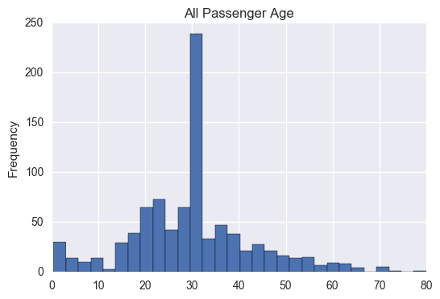

```python
###  全体乘客年龄分布图
df['Age'].plot.hist(bins=30,title='All Passenger Age')
```

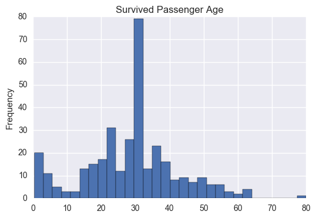

```python
### 生还乘客年龄分布图
survived_passenger_df['Age'].plot.hist(bins=30,title='Survived Passenger Age')
```

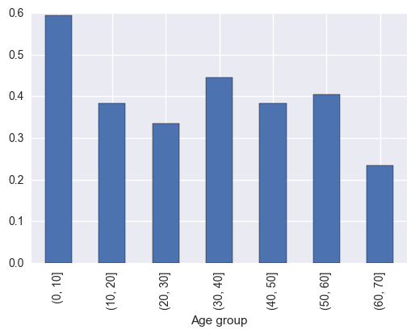

```python
### 依照年龄分组，计算平均值，得到存活率分布
bins = np.arange(0,80,10)
df['Age group'] = pd.cut(df['Age'],bins)
by_Age = df.groupby(['Age group'])['Survived']
by_Age.mean().plot(kind = 'bar')
```

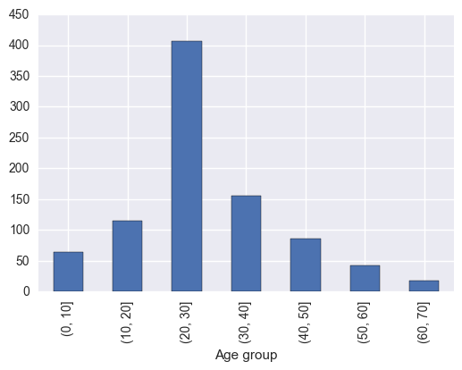

```python
### 依照年龄分组，统计存活人数在不同年龄组的情况
bins = np.arange(0,80,10)
df['Age group'] = pd.cut(df['Age'],bins)
by_Age = df.groupby(['Age group'])['Survived']
by_Age.count().plot(kind = 'bar')
```

```python
survived_passenger_df['Age'].mean()
```

```
28.54977812177503
```

```python
df['Age'].mean()
```

```
29.699117647058763
```

结论1: 从直方图可以看出，粗略观察，两者分布接近，整体均值接近。但从年龄分组分析以后发现0-10岁人群生存率显著高于其他组。

#### 4.2 分析生存率是否与舱位等级（Pclass）有关系

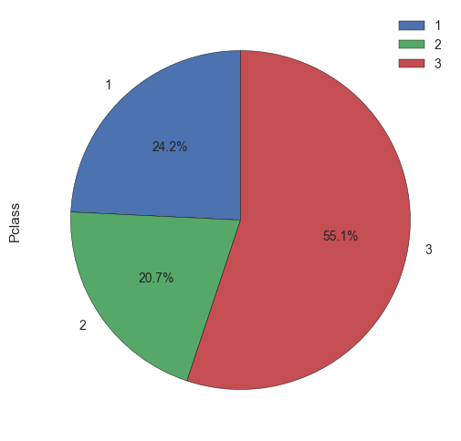

```python
### 全员舱位等级比例图

df.groupby('Pclass')['Pclass'].count().plot.pie(figsize=(6, 6),autopct='%3.1f%%',startangle = 90,legend=True)
```

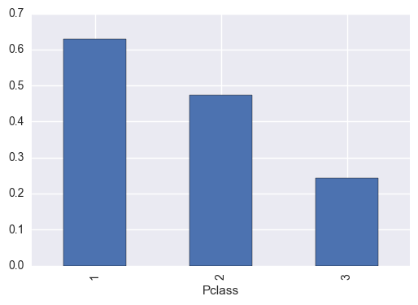

```python
### 绘制舱位不同，生存率均值情况
by_Pclass = df.groupby('Pclass')['Survived'].mean()
by_Pclass.plot(kind = 'bar')
```

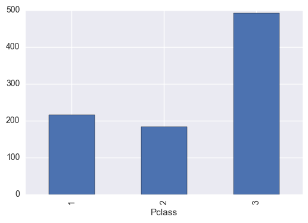

```python
### 绘制不同舱位的人数情况
by_Pclass = df.groupby('Pclass')['Survived'].count()
by_Pclass.plot(kind = 'bar')
```

### 结论2： 从饼图和柱状图看出，生还者舱位，等级越高，生还比例越大，1等舱位大于2等舱位大于3等舱位。

#### 4.3 分析生存率是否与性别有关系

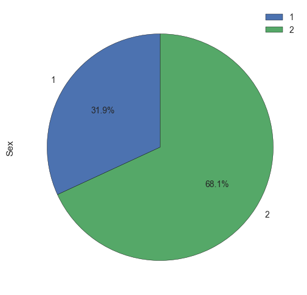

```python
### 生还者性别比例  1为男，2为女
survived_passenger_df.groupby('Sex')['Sex'].count().plot.pie(figsize=(6, 6),autopct='%3.1f%%',startangle = 90,legend=True)
```

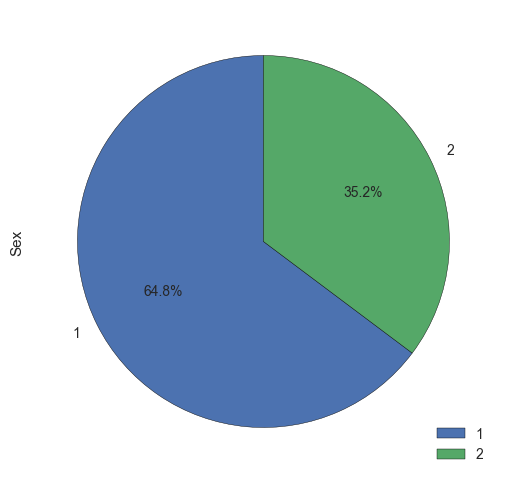

```python
### 全员性别比例  1为男，2为女
df.groupby('Sex')['Sex'].count().plot.pie(figsize=(6, 6),autopct='%3.1f%%',startangle = 90,legend=True)
```

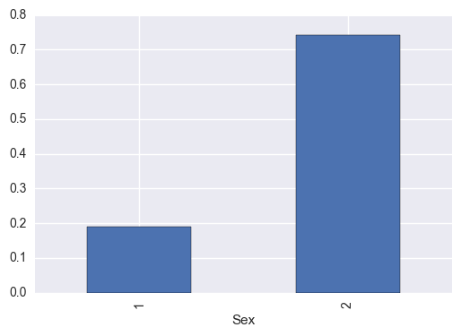

```python
### 绘制性别不同，生存率均值情况，1为男性，2位女性
by_Sex = df.groupby('Sex')['Survived'].mean()
by_Sex.plot(kind = 'bar')
```

### 结论3： 从饼图看出，女性占生还者68%，而占全员35%。从性别分组图中可以得知，女性生成率高于男性。

### 总结

分析结果

> - 由此可见，对于生存率的影响，年龄影响较弱，但0-10岁人群生存率显著较高。
> - 性别影响显著，女性生存率显著较高。
> - 乘坐的舱位也影响生存率。舱位等级越高，生存率越高。

数据缺失值影响

- 局限性，从目前来看，年龄对生存率影响较弱，本次分析年龄缺失值数量较多，且采用了平均值来代替全部缺失值。所以可能分析有偏颇。如果此部分没有缺失值，关于年龄的分析可能会更精确。

其他可能的影响

- 其他可能的因素，本次分析主要从年龄，性别，舱位等级进行了分析，实际上生存率还有可能被职业，体力等诸多因素影响。

结果的相关性

- 这里的数据并非是通过试验得出，所以无法说自变量和因变量之间有因果性，只能说它们之间有相关性。